# Predicting Quality of Dumbbel exercise

Charilaos L

The goal of this project is to use maching learning algorithms to predict the quality of a Unilateral Dumbbel Biceps Curl exercise. We have data on six young healthy participants that were asked to perform 10 repetions of this exercise in five different fashions: exactly according to the specification (Class A), throwing the elbows to the front (Class B), lifting the dumbbel only halfway (Class C), lowering the dumbbel only halfway (Class D) and throwing the hips to the front (Class E).

## Loading the Data

The data are available in http://groupware.les.inf.puc-rio.br/har. They are split in training and test datasets that we download like this:

```r
library(RCurl)
```

```r
myfile <- getURL('https://d396qusza40orc.cloudfront.net/predmachlearn/pml-training.csv', ssl.verifyhost=FALSE, ssl.verifypeer=FALSE)
training<-read.csv(textConnection(myfile),header=T,na.strings=c('',"NA"))
myfile2 <- getURL('https://d396qusza40orc.cloudfront.net/predmachlearn/pml-testing.csv', ssl.verifyhost=FALSE, ssl.verifypeer=FALSE)
testing<-read.csv(textConnection(myfile2),header=T,na.strings=c('',"NA"))
```

```r
dim(training)
```

```
## [1] 19622   160
```

We can see that there are 19622 observations with 160 variables for each observation. However, most of the columns include missing values. So the next step is to clean the data to remove those variables.

## Cleaning the data

```r
training<-training[,(colSums(is.na(training))==0)]
testing<-testing[,(colSums(is.na(testing))==0)]
dim(training)
```

```
## [1] 19622    60
```

```r
dim(testing)
```

```
## [1] 20 60
```

We have reduced our variables to 60. Still we have a lot of information for a prediction model. Therefore, we remove all the non-numeric variables

```r
numericalColumns<-which(lapply(training,class) %in% "numeric")
numericalColumns<-c(numericalColumns,60)
training<-training[,numericalColumns]
testing<-testing[,numericalColumns]
dim(training);dim(testing)
```

```
## [1] 19622    28
```

```
## [1] 20 28
```

## Training and validation subsets

First we create a training subset with 75% of the original training data and the remaining observations are used for validation.

```r
set.seed(12031987)
library(caret)
InTrain<-createDataPartition(training$classe,p=3/4,list=FALSE)
training2<-training[InTrain,]
validation<-training[-InTrain,]
dim(training2);dim(validation)
```

```
## [1] 14718    28
```

```
## [1] 4904   28
```

## Prediction Models

We start our exploration of machine learning algorithms with a decision tree:

```r
set.seed(125)
library(rpart)
fitDecTree<-train(classe~.,method='rpart',data=training2)
print(fitDecTree$finalModel)
```

```
## n= 14718
##
## node), split, n, loss, yval, (yprob)
##       * denotes terminal node
##
##  1) root 14718 10533 A (0.28 0.19 0.17 0.16 0.18)
##    2) roll_belt< 130.5 13503  9329 A (0.31 0.21 0.19 0.18 0.11)
##      4) pitch_forearm< -33.9 1178    10 A (0.99 0.0085 0 0 0) *
##      5) pitch_forearm>=-33.9 12325  9319 A (0.24 0.23 0.21 0.2 0.12)
##       10) yaw_belt>=169.5 591    60 A (0.9 0.044 0 0.049 0.0085) *
##       11) yaw_belt< 169.5 11734  8922 B (0.21 0.24 0.22 0.2 0.13)
##         22) magnet_dumbbell_z< -93.5 1428   583 A (0.59 0.28 0.046 0.055 0.027) *
##         23) magnet_dumbbell_z>=-93.5 10306  7805 C (0.16 0.23 0.24 0.22 0.14)
##           46) pitch_belt< -42.95 625   103 B (0.019 0.84 0.1 0.021 0.024) *
##           47) pitch_belt>=-42.95 9681  7243 C (0.17 0.2 0.25 0.24 0.15)
##             94) roll_dumbbell< 59.05733 6211  4055 C (0.19 0.16 0.35 0.18 0.12) *
##             95) roll_dumbbell>=59.05733 3470  2269 D (0.13 0.25 0.081 0.35 0.2) *
##    3) roll_belt>=130.5 1215    11 E (0.0091 0 0 0 0.99) *
```

```r
ModelDecTree<-predict(fitDecTree,validation)
confusionMatrix(ModelDecTree,validation$classe)
```

```
## Confusion Matrix and Statistics
##
##           Reference
## Prediction   A   B   C   D   E
##          A 849 143  23  44   7
##          B   0 158  12   8   5
##          C 390 371 722 356 231
##          D 153 277  98 396 231
##          E   3   0   0   0 427
##
## Overall Statistics
##
##                Accuracy : 0.5204
##                  95% CI : (0.5063, 0.5345)
##     No Information Rate : 0.2845
##     P-Value [Acc > NIR] : < 2.2e-16
##
##                   Kappa : 0.4025
##  Mcnemar's Test P-Value : < 2.2e-16
##
## Statistics by Class:
##
##                      Class: A Class: B Class: C Class: D Class: E
## Sensitivity            0.6086  0.16649   0.8444  0.49254  0.47392
## Specificity            0.9382  0.99368   0.6671  0.81488  0.99925
## Pos Pred Value         0.7964  0.86339   0.3488  0.34286  0.99302
## Neg Pred Value         0.8577  0.83245   0.9531  0.89117  0.89405
## Prevalence             0.2845  0.19352   0.1743  0.16395  0.18373
## Detection Rate         0.1731  0.03222   0.1472  0.08075  0.08707
## Detection Prevalence   0.2174  0.03732   0.4221  0.23552  0.08768
## Balanced Accuracy      0.7734  0.58008   0.7558  0.65371  0.73658
```

Since the decision tree model was quite inaccurate, we test if a Random Forest fits the data more appropriately

```r
set.seed(125)
library(randomForest)
```

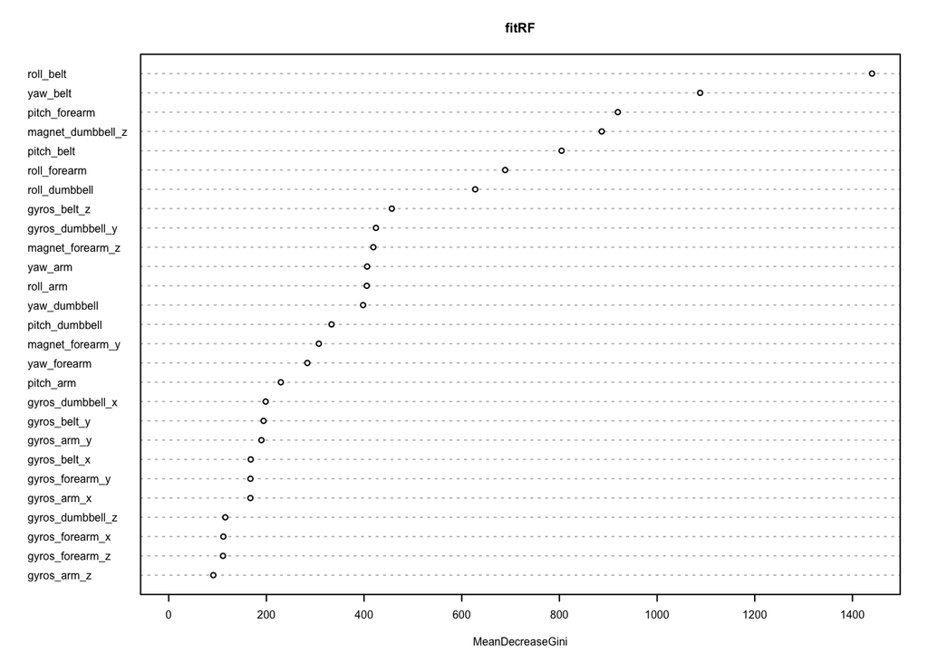

```r
fitRF<-randomForest(classe~.,data=training2)
ModelRF<-predict(fitRF,validation)
varImpPlot(fitRF,cex=.5)
```

```r
confusionMatrix(ModelRF,validation$classe)
```

```
## Confusion Matrix and Statistics
##
##           Reference
## Prediction    A    B    C    D    E
##          A 1394    3    0    0    0
##          B    1  944    4    0    0
##          C    0    2  850    4    1
##          D    0    0    0  798    4
##          E    0    0    1    2  896
##
## Overall Statistics
##
##                Accuracy : 0.9955
##                  95% CI : (0.9932, 0.9972)
##     No Information Rate : 0.2845
##     P-Value [Acc > NIR] : < 2.2e-16
##
##                   Kappa : 0.9943
##  Mcnemar's Test P-Value : NA
##
## Statistics by Class:
##
##                      Class: A Class: B Class: C Class: D Class: E
## Sensitivity            0.9993   0.9947   0.9942   0.9925   0.9945
## Specificity            0.9991   0.9987   0.9983   0.9990   0.9993
## Pos Pred Value         0.9979   0.9947   0.9918   0.9950   0.9967
## Neg Pred Value         0.9997   0.9987   0.9988   0.9985   0.9988
## Prevalence             0.2845   0.1935   0.1743   0.1639   0.1837
## Detection Rate         0.2843   0.1925   0.1733   0.1627   0.1827
## Detection Prevalence   0.2849   0.1935   0.1748   0.1635   0.1833
## Balanced Accuracy      0.9992   0.9967   0.9962   0.9958   0.9969
```

## Out-of-Sample Error

Given the accuracy of the Random Forest on the validation dataset, we calculate below the out-of-sample error

```r
out_of_sample_error<-1-confusionMatrix(ModelRF,validation$classe)$overall[[1]]
out_of_sample_error
```

```
## [1] 0.004486134
```

When the model is applied to the 20 test cases provided the results are shown below

```r
predFinal<-predict(fitRF,testing)
predFinal
```

```
##  1  2  3  4  5  6  7  8  9 10 11 12 13 14 15 16 17 18 19 20
##  B  A  B  A  A  E  D  B  A  A  B  C  B  A  E  E  A  B  B  B
## Levels: A B C D E
```